# SELECTION SIGNATURES - POPULATION GENETICS

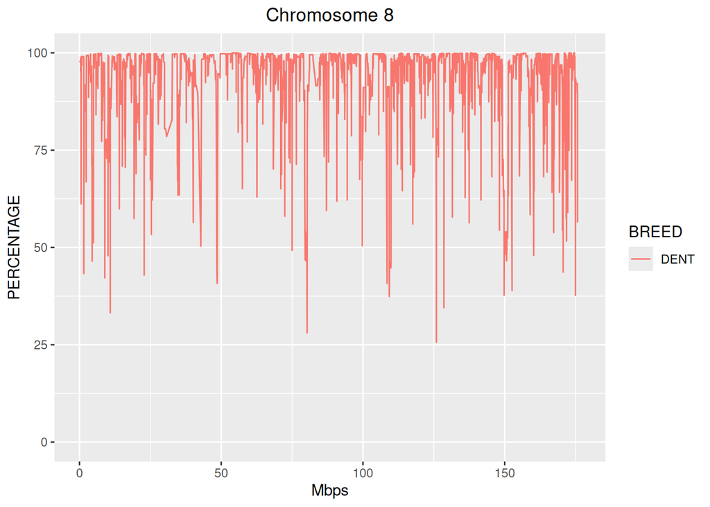

```r
# Zoom Específico no Cromossomo 8 (Hotspot do gene TT12) - DENT
plot_SnpsInRuns(
  runs         = rohom_DENT[rohom_DENT$chrom == 8, ],
  genotypeFile = files_dent$ped,
  mapFile      = files_dent$map
)
```

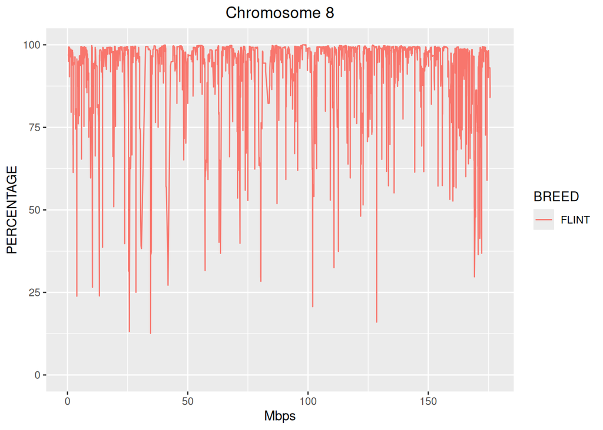

```r
# Zoom Específico no Cromossomo 8 (Hotspot do gene TT12) - FLINT
plot_SnpsInRuns(
  runs         = rohom_FLINT[rohom_FLINT$chrom == 8, ],
  genotypeFile = files_flint$ped,
  mapFile      = files_flint$map
)
```

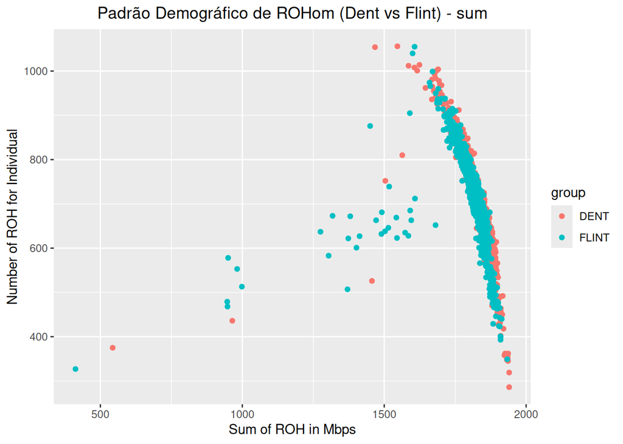

```r
# Porcentagem de SNPs em ROH no Cromossomo 1 (DENT vs FLINT)
# plot_SnpsInRuns(
#   runs         = all_rohom[all_rohom$chrom == 1, ],
#   genotypeFile = files_dent$ped,
#   mapFile      = files_dent$map
# )

# Empilhamento de corridas no Cromossomo 8
# plot_StackedRuns(
#   runs         = all_rohom[all_rohom$chrom == 8, ],
#   savePlots    = FALSE
# )

# Método Soma: Tamanho total do genoma em ROH vs Número de ROHs
# Padrão Demográfico (Soma Total vs Nº de ROHs)
plot_PatternRuns(
  runs      = all_rohom,
  mapFile   = files_dent$map,
  method    = "sum",
  plotTitle = "Padrão Demográfico de ROHom (Dent vs Flint)"
)
```

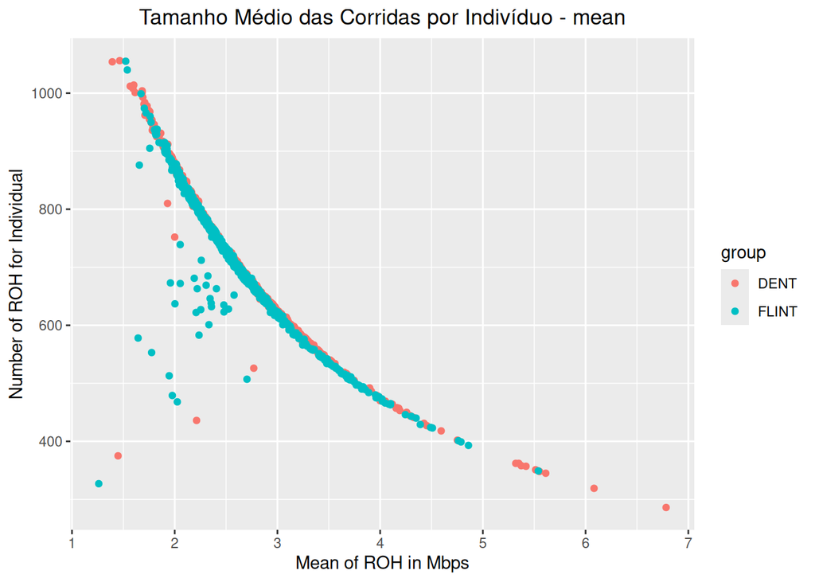

```r
# Tamanho Médio das Corridas vs Nº de ROHs
plot_PatternRuns(
  runs      = all_rohom,
  mapFile   = files_dent$map,
  method    = "mean",
  plotTitle = "Tamanho Médio das Corridas por Indivíduo"
)
```

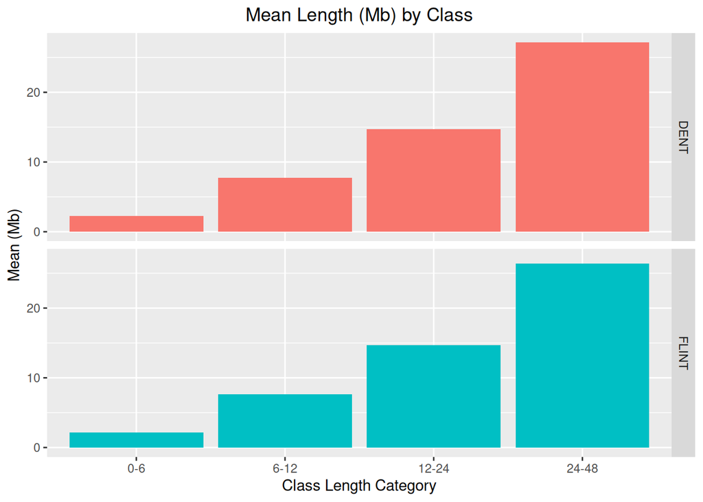

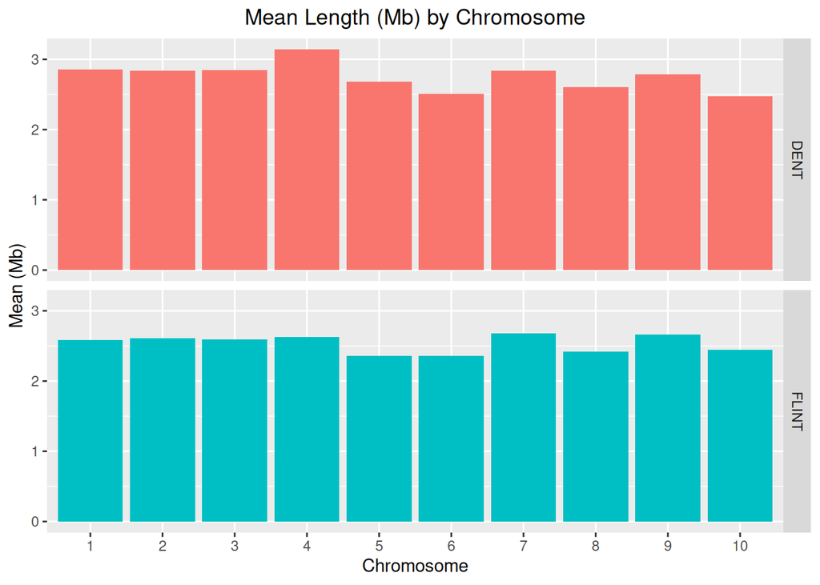

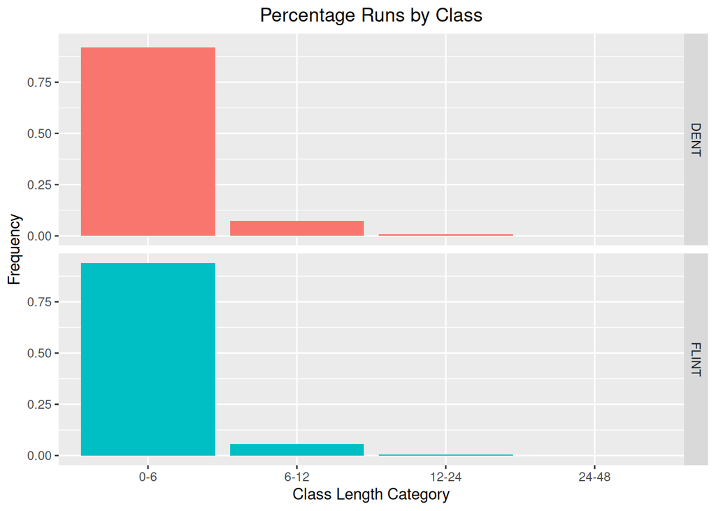

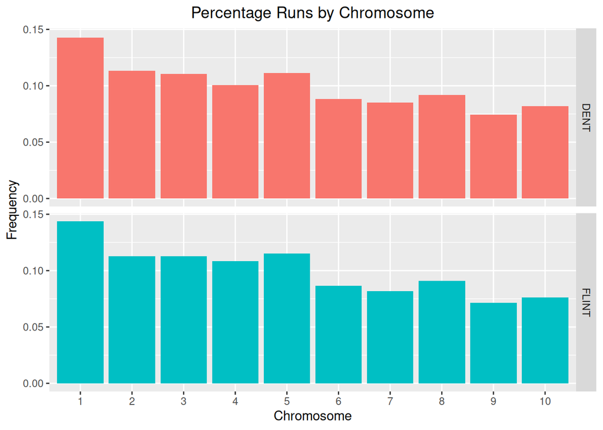

```r
# Distribuição de ROH por Classe de Tamanho e Cromossomo (Class = 6 para alinhar com o summary)
plot_DistributionRuns(
  runs       = all_rohom,
  mapFile    = files_dent$map,
  groupSplit = TRUE,
  style      = "All",
  Class      = 6
)
```

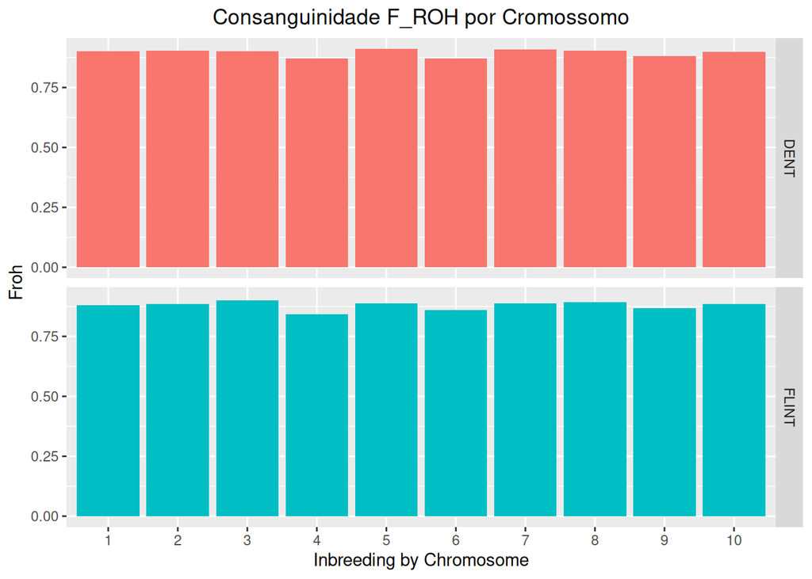

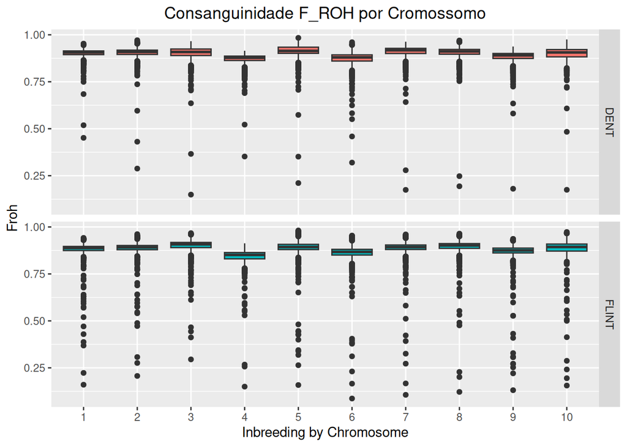

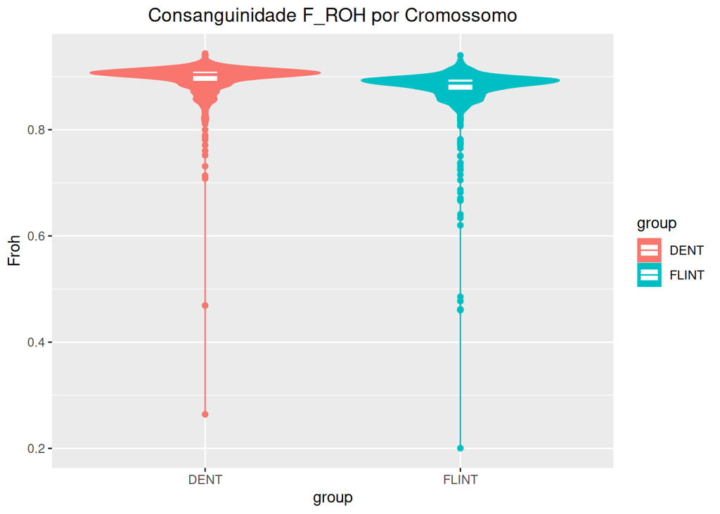

```r
plot_InbreedingChr(
  runs       = all_rohom,
  mapFile    = files_dent$map,
  groupSplit = TRUE,
  style      = "All",
  plotTitle  = "Consanguinidade F_ROH por Cromossomo"
)
```

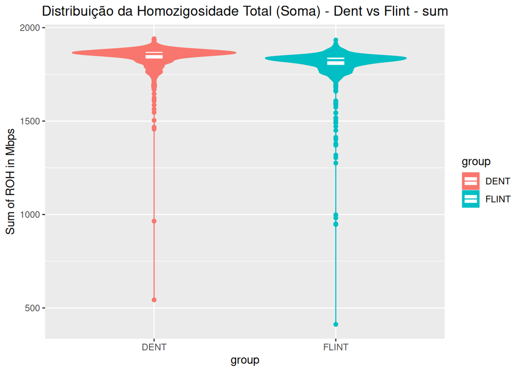

```r
plot_ViolinRuns(
  runs      = all_rohom,
  method    = "sum",
  plotTitle = "Distribuição da Homozigosidade Total (Soma) - Dent vs Flint"
)
```

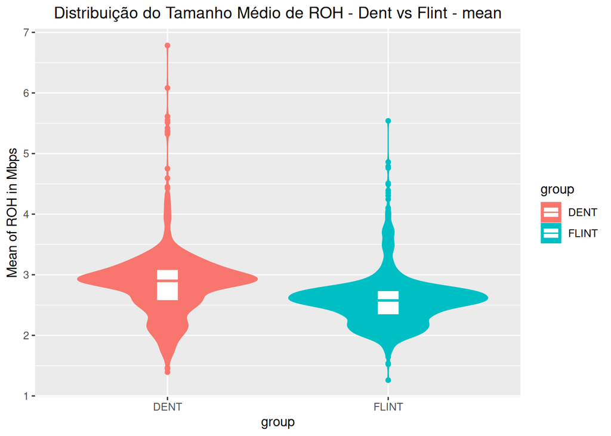

```r
# Violino: Tamanho Médio de ROH por Indivíduo
plot_ViolinRuns(
  runs      = all_rohom,
  method    = "mean",
  plotTitle = "Distribuição do Tamanho Médio de ROH - Dent vs Flint"
)
```

```r
# Plota todas as corridas individuais para o Cromossomo 1
# plot_Runs(
#   runs         = all_rohom[all_rohom$chrom == 1, ],
#   suppressInds = TRUE, # Oculta os nomes dos 2000+ indivíduos no eixo Y para não poluir
#   savePlots    = FALSE
# )
# plot_Runs(
#   runs         = all_rohom[all_rohom$chrom == 1, ],
#   suppressInds = TRUE, # Oculta os nomes dos 2000+ indivíduos no eixo Y para não poluir
#   savePlots    = FALSE
# )
```

```r
cat("=== RESUMO POPULACIONAL - MARRAS ET AL., 2015) ===\n")
## === RESUMO POPULACIONAL - MARRAS ET AL., 2015) ===
print(tabela_marras_resumo)
```

```
##   Populacao                     Tipo N_Individuos N_Runs_Total Mean_Runs_Ind
## 1      DENT   ROHom (Homozigosidade)         1005       667975  664.65174129
## 2     FLINT   ROHom (Homozigosidade)         1262       899790  712.98732171
## 3      DENT ROHet (Heterozigosidade)         1005           68    0.06766169
## 4     FLINT ROHet (Heterozigosidade)         1262          259    0.20522979
##   Mean_F_coeff  Sd_F_coeff
## 1  0.877107193 0.034329878
## 2  0.860822579 0.043237093
## 3  0.011610505 0.007838306
## 4  0.007265157 0.007719181
```

```r
# Visualizar as principais regiões candidatas
cat("=== ILHAS DE ROHom EM DENT (> 40% FREQUÊNCIA) ===\n")
## === ILHAS DE ROHom EM DENT (> 40% FREQUÊNCIA) ===
print(head(ilhas_DENT_40))
```

```
##   Group     Start_SNP       End_SNP chrom nSNP     from       to
## 1  DENT         SYN83 PZE-101083407     1 1772     3498 71025618
## 2  DENT PZE-101083417 PZE-101083417     1    1 71051198 71051198
## 3  DENT PZE-101083422 PZE-101084367     1   46 71063691 72842586
## 4  DENT PZE-101084453 PZE-101087582     1   99 73102340 78049104
## 5  DENT PZE-101087587 PZE-101089457     1   55 78216208 81076470
## 6  DENT      SYN35629 PZE-101100532     1  282 81106413 96683279
```

```r
cat("\n=== ILHAS DE ROHom EM FLINT (> 40% FREQUÊNCIA) ===\n")
```

```
##
## === ILHAS DE ROHom EM FLINT (> 40% FREQUÊNCIA) ===
```

```r
print(head(ilhas_FLINT_40))
```

```
##   Group     Start_SNP       End_SNP chrom nSNP     from       to
## 1 FLINT PZE-101000060 PZE-101000760     1   28   157104  1748915
## 2 FLINT       SYN9660 PZE-101039655     1  690  1781003 26948708
## 3 FLINT PZE-101040594 PZE-101052733     1  227 27379439 36800951
## 4 FLINT PZE-101052767      SYN29860     1  104 36830744 41854735
## 5 FLINT      SYN37299 PZE-101083423     1  723 41956983 71063759
## 6 FLINT PZE-101083533 PZE-101084361     1   42 71145092 72820226
```

```r
# Objetos gerados no resumo (prontos para exportar em .csv):
head(summary_DENT$summary_ROH_mean_class)    # Média de ROH por classe de tamanho
```

```
##   CLASS      DENT
## 1   0-6  2.276967
## 2  6-12  7.757606
## 3 12-24 14.727207
## 4 24-48 27.136636
```

```r
head(summary_DENT$result_Froh_class)          # F_ROH individual particionado por classe
```

```
##          id group Sum_Class_0 Froh_Class_0 Sum_Class_6 Froh_Class_6
## 1 CFD01.003  DENT  1842747271    0.8959269   454436906   0.22094308
## 2 CFD01.006  DENT  1820681944    0.8851990   351721035   0.17100356
## 3 CFD01.008  DENT  1861318589    0.9049561   453065806   0.22027646
## 4 CFD01.009  DENT  1834232117    0.8917869   372307150   0.18101234
## 5 CFD01.010  DENT  1861492593    0.9050407   536100394   0.26064712
## 6 CFD01.011  DENT  1606454581    0.7810436    61299263   0.02980314
##   Sum_Class_12 Froh_Class_12 Sum_Class_24 Froh_Class_24
## 1     47040028   0.022870433           NA            NA
## 2     28253498   0.013736593           NA            NA
## 3     41102021   0.019983428           NA            NA
## 4     45170598   0.021961533           NA            NA
## 5     80882829   0.039324494     24051071    0.01169341
## 6     12146703   0.005905616           NA            NA
```

```r
head(summary_DENT$result_Froh_chromosome_wide) # F_ROH individual por cromossomo
```

```
##          id group     Chr_1     Chr_2     Chr_3     Chr_4     Chr_5     Chr_6
## 1 CFD01.003  DENT 0.9209259 0.8954910 0.8977631 0.8540185 0.9093253 0.8687646
## 2 CFD01.006  DENT 0.9033374 0.9027694 0.8879179 0.8503113 0.8932753 0.8583518
## 3 CFD01.008  DENT 0.9101846 0.9229633 0.9244003 0.8724979 0.9178294 0.8847223
## 4 CFD01.009  DENT 0.8903823 0.8905788 0.9016669 0.8576387 0.9224818 0.8535503
## 5 CFD01.010  DENT 0.9189560 0.9023234 0.9108220 0.8786333 0.9155619 0.8693054
## 6 CFD01.011  DENT 0.7792044 0.8164326 0.8037877 0.7675683 0.7772378 0.7382919
##       Chr_7     Chr_8     Chr_9    Chr_10
## 1 0.9076022 0.9222245 0.8645351 0.9103955
## 2 0.9078779 0.8759122 0.8807036 0.8803913
## 3 0.8829606 0.9053535 0.8992534 0.9235752
## 4 0.9207953 0.8801356 0.8923255 0.9137407
## 5 0.9277423 0.9265539 0.8712648 0.9233311
## 6 0.7791166 0.7849089 0.7363546 0.8134330
```

```r
head(summary_FLINT$summary_ROH_mean_class)    # Média de ROH por classe de tamanho
```

```
##   CLASS     FLINT
## 1   0-6  2.177077
## 2  6-12  7.661713
## 3 12-24 14.721154
## 4 24-48 26.352714
```

```r
head(summary_FLINT$result_Froh_class)          # F_ROH individual particionado por classe
```

```
##           id group Sum_Class_0 Froh_Class_0 Sum_Class_6 Froh_Class_6
## 1 CFF01-001. FLINT  1867722563    0.9080697   606596518    0.2949217
## 2 CFF01-003. FLINT  1866864462    0.9076525   581979112    0.2829529
## 3 CFF01-004. FLINT  1867213909    0.9078224   532141435    0.2587223
## 4 CFF01-005. FLINT  1855081129    0.9019235   520712937    0.2531659
## 5 CFF01-007. FLINT  1861361248    0.9049769   589659519    0.2866871
## 6 CFF01-010. FLINT  1879713766    0.9138997   565136138    0.2747640
##   Sum_Class_12 Froh_Class_12 Sum_Class_24 Froh_Class_24
## 1    131199369    0.06378794     24051071    0.01169341
## 2     75254754    0.03658818           NA            NA
## 3     80620762    0.03919708     24051071    0.01169341
## 4     46380074    0.02254957           NA            NA
## 5     52509860    0.02552982           NA            NA
## 6    111785989    0.05434933     24051071    0.01169341
```

```r
head(summary_FLINT$result_Froh_chromosome_wide) # F_ROH individual por cromossomo
```

```
##           id group     Chr_1     Chr_2     Chr_3     Chr_4     Chr_5     Chr_6
## 1 CFF01-001. FLINT 0.9159900 0.9241915 0.9264001 0.8822125 0.9311894 0.8664488
## 2 CFF01-003. FLINT 0.8956654 0.9228170 0.9112607 0.8740214 0.9369950 0.8769395
## 3 CFF01-004. FLINT 0.9103936 0.9149439 0.9125800 0.8904745 0.9200526 0.8830077
## 4 CFF01-005. FLINT 0.9064598 0.9156218 0.9159824 0.8658588 0.9105979 0.8638359
## 5 CFF01-007. FLINT 0.9075441 0.9232714 0.9312273 0.8732709 0.9304147 0.8670058
## 6 CFF01-010. FLINT 0.9093566 0.9057025 0.9269829 0.8822029 0.9431218 0.9030900
##       Chr_7     Chr_8     Chr_9    Chr_10
## 1 0.8794387 0.9367599 0.8817766 0.9207440
## 2 0.9326826 0.9283762 0.8878246 0.9153461
## 3 0.9220111 0.9084229 0.8865811 0.9269889
## 4 0.9324036 0.9055832 0.8907309 0.9093761
## 5 0.8843997 0.9337539 0.8581538 0.9265210
## 6 0.9374173 0.9110641 0.8995334 0.9271926
```

Quantitative evaluation of continuous runs using the consecutive method implemented in detectRUNS establishes the quantitative baseline necessary to distinguish background inbreeding from localized selection signatures. Across the genome, runs of homozygosity (ROHom) dominated total variation, with the Dent panel ($N = 1005$) accumulating 667,975 total runs averaging 664.65 runs per individual ($F_{ROHom} = 0.8771 \pm 0.0343$), and the Flint panel ($N = 1262$) displaying 899,790 total runs averaging 712.99 runs per individual ($F_{ROHom} = 0.8608 \pm 0.0432$). Conversely, runs of heterozygosity (ROHet) were virtually absent, totaling only 68 runs in Dent ($0.0677$ runs per individual; $F_{ROHet} = 0.0116 \pm 0.0078$) and 259 runs in Flint ($0.2052$ runs per individual; $F_{ROHet} = 0.0073 \pm 0.0077$). While this massive disparity confirms near-complete genomic fixation resulting from colchicine-induced chromosome doubling, uniform background autozygosity alone cannot explain why specific genomic regions coalesce into homozygous blocks across hundreds of independently derived lines.

When directional selection operates on target agronomic loci, genetic hitchhiking drives the beneficial allele and its surrounding chromosomal background toward fixation faster than recombination can fragment the ancestral haplotype. This process leaves distinct selection signatures manifested as high-density ROH islands, where the proportion of individuals sharing autozygous segments significantly exceeds the genome-wide average. Scanning for regions where ROHom occurrence surpassed 40% of the population uncovered prominent selection signatures, most notably along Chromosome 1. In the Dent panel, a massive multi-megabase ROH island spanned from 3,498 bp to 71,025,618 bp (SYN83 to PZE-101083407, encompassing 1,772 contiguous SNPs), flanked downstream by dense selective sweep blocks such as the 81.11 Mb to 96.68 Mb interval (282 SNPs). In the Flint panel, Chromosome 1 similarly exhibited major selection signatures, including continuous autozygous tracts spanning 1.78 Mb to 26.95 Mb (SYN9660 to PZE-101039655, 690 SNPs) and 41.96 Mb to 71.06 Mb (SYN37299 to PZE-101083423, 723 SNPs).

The accumulation of these extensive ROH islands on Chromosome 1 provides compelling evidence of strong artificial selection applied during the development and heterotic separation of Dent and Flint inbred lines. Because stochastic genetic drift and doubled haploid induction generate a uniform distribution of autozygosity across the genome, contiguous homozygous blocks maintained at frequencies above 40% signal conserved ancestral haplotypes harboring critical agronomic genes. Furthermore, the divergence in specific island boundaries and SNP densities between Dent and Flint highlights differential selective pressures targeting distinct traits in each pool, such as grain texture, cold tolerance, and flowering time. Cross-validating these Chromosome 1 ROH hotspots with extreme population differentiation ($\theta > 0.33$), site frequency spectrum distortions ($D \le -0.96$), and long-range haplotype homozygosity ($\vert{}iHS\vert{} > 5.0$) provides robust multi-method confirmation of primary selection signatures that shaped the genomic architecture of elite maize germplasm.

### Single-Site Population Differentiation

Single-site population differentiation methods identify selection signatures by evaluating allele frequency differences at individual loci across populations. The primary metrics in this category are the fixation index ($F_{ST}$) and $FLK$. While $FLK$ incorporates a population kinship matrix ($F$-matrix) to account for hierarchical branching and dynamic changes in effective population size, $F_{ST}$ remains the standard metric for measuring locus-by-locus differentiation.

Originally proposed by Wright, $F_{ST}$ ranges from 0 (no differentiation) to 1 (complete fixation of alternative alleles between populations). High $F_{ST}$ values at a given locus point to divergent positive selection, where distinct environmental pressures or breeding objectives drive allele frequencies apart. A key advantage of $F_{ST}$ over SFS or LD methods is its site-specific resolution, which helps isolate the exact variants or narrow regions under selection.

In this analysis, we will use $F_{ST}$, based on the Weir & Cockerham (1984) methodology, to evaluate locus-specific differentiation between the Dent and Flint germplasm groups. To reduce single-SNP noise and false-positive signals, $F_{ST}$ values will be scanned across sliding genomic windows to identify robust candidate regions under divergent selection.

$F = F_{IT}$ $\theta = F_{ST}$ $f = F_{IS}$

Weir and Cockerham maintain the notation $F$, $\theta$, and $f$ throughout their framework because these quantities are defined as population parameters, independent of the specific details of the sampling scheme.

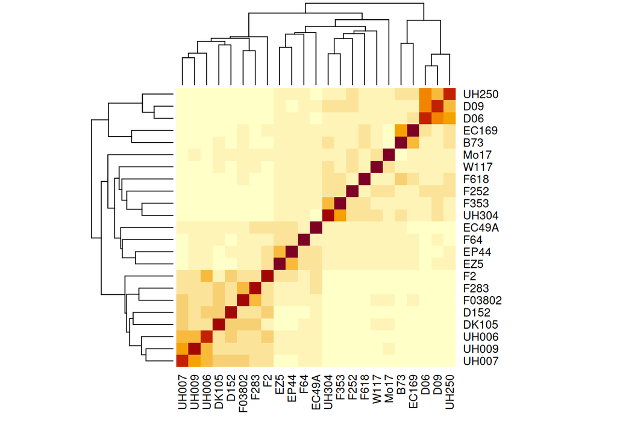

```r
# FUNÇÃO MATRIZ G DE VANRADEN

calcular_G_VanRaden <- function(M) {
  if (is.list(M) && !is.data.frame(M)) {
    M <- M$M
  }

  M <- as.matrix(M)
  mode(M) <- "numeric"
  if (nrow(M) > ncol(M)) {
    M <- t(M)
  }

  n_ind <- nrow(M)
  p <- colMeans(M, na.rm = TRUE) / 2
  P <- matrix(2 * p, nrow = n_ind, ncol = ncol(M), byrow = TRUE)

  Z <- M - P
  Z[is.na(Z)] <- 0
  Numerador <- Z %*% t(Z)
  Denominador <- 2 * sum(p * (1 - p), na.rm = TRUE)
  G <- Numerador / Denominador
  return(G)
}

################################################################################

G_Parental <- calcular_G_VanRaden(matriz_Parental)
G_CFDENT <- calcular_G_VanRaden(matriz_CFDENT)
G_CFFLINT <- calcular_G_VanRaden(matriz_CFFLINT)

# class(G_Parental)
# class(G_CFDENT)
# class(G_CFFLINT)

heatmap(G_Parental)
```

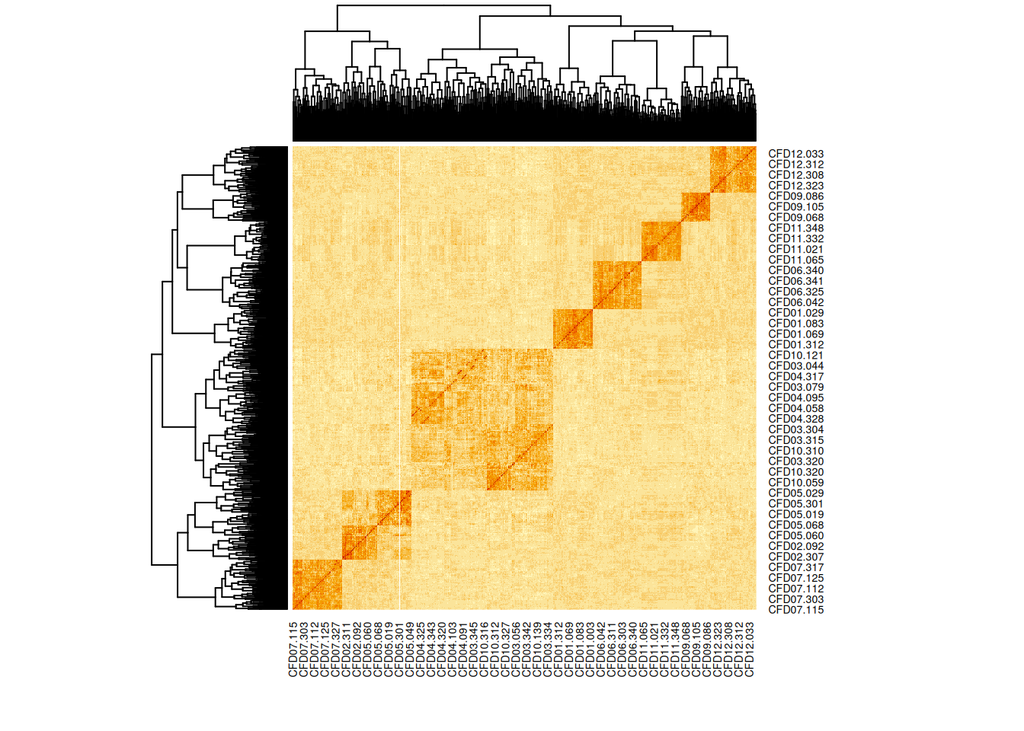

```r
heatmap(G_CFDENT)
```

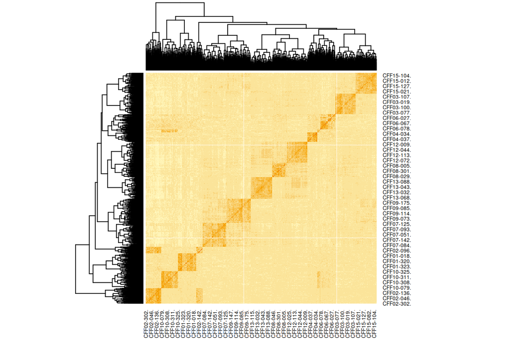

```r
heatmap(G_CFFLINT)
```

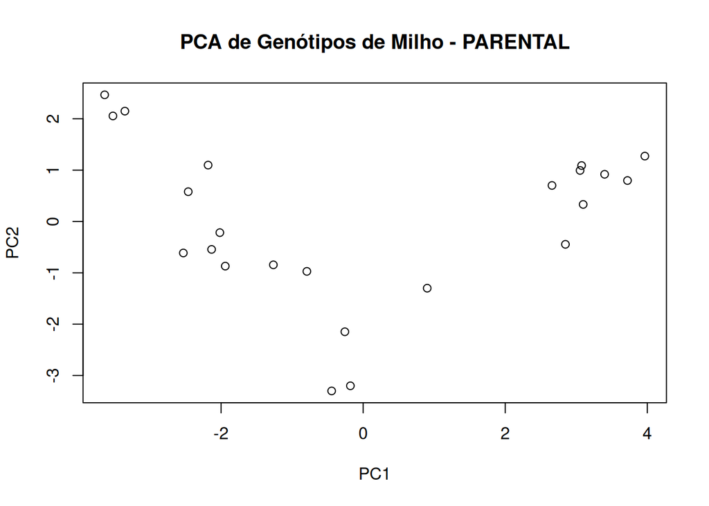

```r
pcA_parental <- prcomp(G_Parental, center = TRUE, scale. = TRUE)
summary(pcA_parental)
scores_PARENTAL <- pcA_parental$x
plot(scores_PARENTAL[,1], scores_PARENTAL[,2],
     xlab = "PC1", ylab = "PC2",
     main = "PCA de Genótipos de Milho - PARENTAL")
```

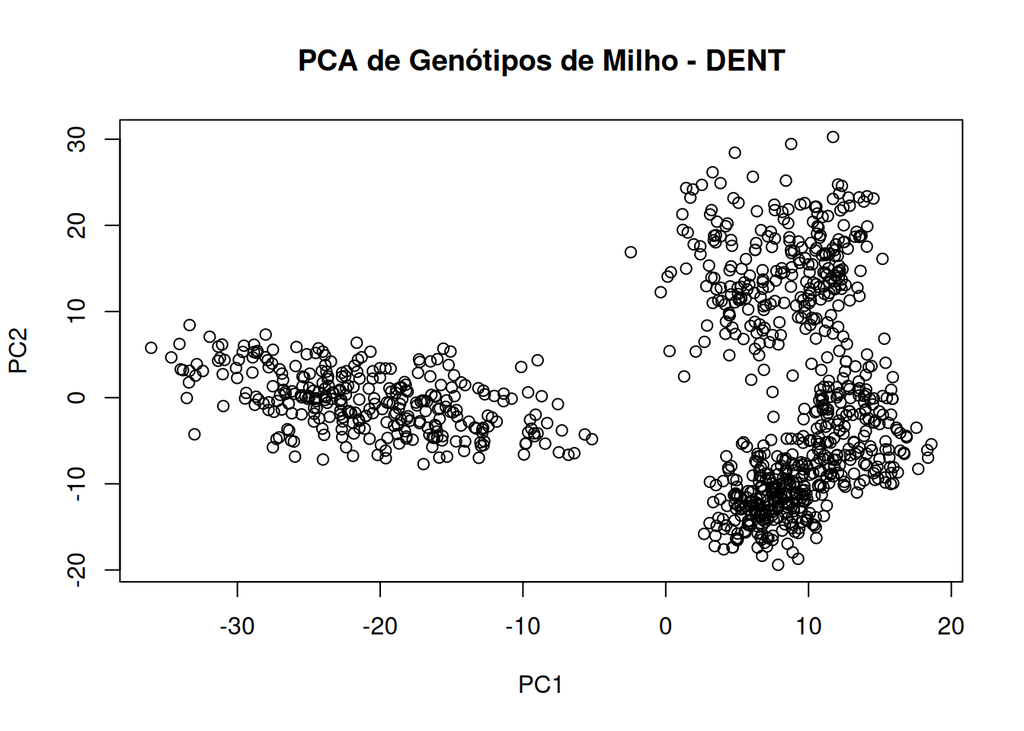

```r
pcA_DENT <- prcomp(G_CFDENT, center = TRUE, scale. = TRUE)
summary(pcA_DENT)
scores_DENT <- pcA_DENT$x
plot(scores_DENT[,1], scores_DENT[,2],
     xlab = "PC1", ylab = "PC2",
     main = "PCA de Genótipos de Milho - DENT")
```

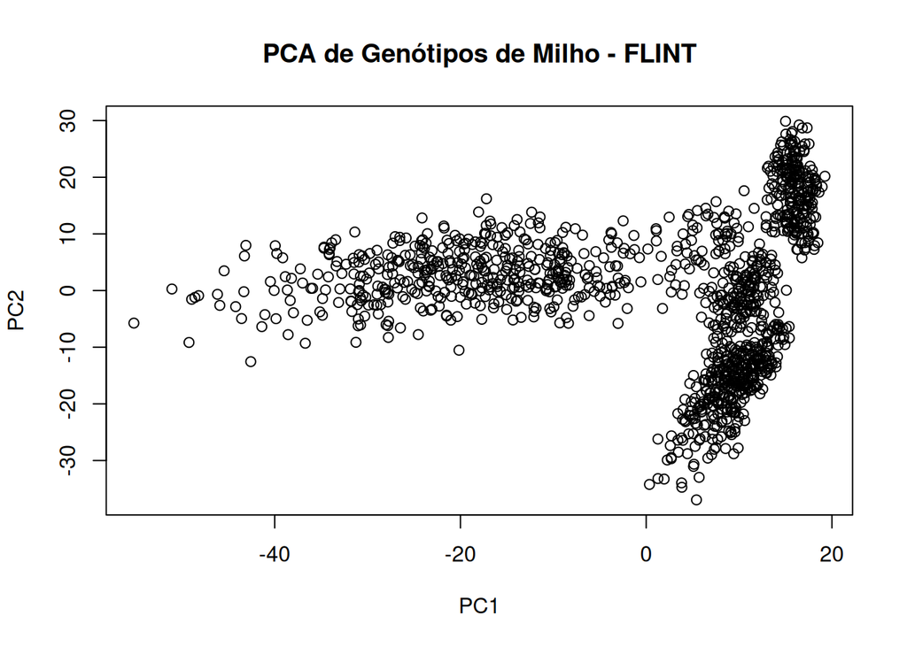

```r
pcA_FLINT <- prcomp(G_CFFLINT, center = TRUE, scale. = TRUE)
summary(pcA_FLINT)
scores_FLINT <- pcA_FLINT$x
plot(scores_FLINT[,1], scores_FLINT[,2],
     xlab = "PC1", ylab = "PC2",
     main = "PCA de Genótipos de Milho - FLINT")
```

```r
#### ver os grupos

distancia_PARENTAL <- dist(G_Parental)
hc_PARENTAL <- hclust(distancia_PARENTAL)

distancia_DENT <- dist(G_CFDENT)
hc_DENT <- hclust(distancia_DENT)

distancia_FLINT <- dist(G_CFFLINT)
hc_FLINT <- hclust(distancia_FLINT)

n_ind_DENT <- nrow(G_CFDENT)
n_ind_FLINT <- nrow(G_CFFLINT)


rm("G_Parental", "G_CFDENT", "G_CFFLINT")
```

#### $F_{ST}$ computation

```r
################################################################################
################################################################################
### DEFINIR NUMERO DE SUBPOPULACOES DENTRO DE FINT E DENT, PELO HEATMAP VOU USAR DENT(R=8), e flint(r=13) (POR CAUSA DO HEAT MAP NA MATRIZ G)

#dent

grupos_dent <- cutree(hc_DENT, k = 8)
df_grupos_dent <- data.frame(
  Genotipo = names(grupos_dent),
  Grupo = as.factor(grupos_dent)
)

ind_grupo1_dent <- names(grupos_dent[grupos_dent == 1])
ind_grupo2_dent <- names(grupos_dent[grupos_dent == 2])
ind_grupo3_dent <- names(grupos_dent[grupos_dent == 3])
ind_grupo4_dent <- names(grupos_dent[grupos_dent == 4])
ind_grupo5_dent <- names(grupos_dent[grupos_dent == 5])
ind_grupo6_dent <- names(grupos_dent[grupos_dent == 6])
ind_grupo7_dent <- names(grupos_dent[grupos_dent == 7])
ind_grupo8_dent <- names(grupos_dent[grupos_dent == 8])

#flint

grupos_flint <- cutree(hc_FLINT, k = 13)
df_grupos_flint <- data.frame(
  Genotipo = names(grupos_flint),
  Grupo = as.factor(grupos_flint)
)

ind_grupo1_flint <- names(grupos_flint[grupos_flint == 1])
ind_grupo2_flint <- names(grupos_flint[grupos_flint == 2])
ind_grupo3_flint <- names(grupos_flint[grupos_flint == 3])
ind_grupo4_flint <- names(grupos_flint[grupos_flint == 4])
ind_grupo5_flint <- names(grupos_flint[grupos_flint == 5])
ind_grupo6_flint <- names(grupos_flint[grupos_flint == 6])
ind_grupo7_flint <- names(grupos_flint[grupos_flint == 7])
ind_grupo8_flint <- names(grupos_flint[grupos_flint == 8])
ind_grupo9_flint <- names(grupos_flint[grupos_flint == 9])
ind_grupo10_flint <- names(grupos_flint[grupos_flint == 10])
ind_grupo11_flint <- names(grupos_flint[grupos_flint == 11])
ind_grupo12_flint <- names(grupos_flint[grupos_flint == 12])
ind_grupo13_flint <- names(grupos_flint[grupos_flint == 13])

################################################################################
################################################################################
# fazer um match e selecionar nas matrizes de dose apenas os snps compartilahdos entre flint e dent

snps_comuns <- intersect(
  colnames(matriz_CFDENT),
  colnames(matriz_CFFLINT)
)

matriz_CFDENT<- matriz_CFDENT[, snps_comuns, drop = FALSE]
matriz_CFFLINT<- matriz_CFFLINT[, snps_comuns, drop = FALSE]
cat("Número de SNPs compartilhados mantidos:", length(snps_comuns), "\n")

################################################################################################################################################################
################################################################################################################################################################
################################################################################################################################################################
################################################################################################################################################################

# calcular os Fs de weir e cockehram (1984)


################################################################################
########## DENT (r = 8 subgrupos)
################################################################################

r_DENT <- 8

# Tamanho amostral médio
n_DENT <- n_ind_DENT / r_DENT

n_i_r_DENT <- c(
  length(ind_grupo1_dent), length(ind_grupo2_dent), length(ind_grupo3_dent),
  length(ind_grupo4_dent), length(ind_grupo5_dent), length(ind_grupo6_dent),
  length(ind_grupo7_dent), length(ind_grupo8_dent)
)

n_c_DENT <- (r_DENT * n_DENT - (sum(n_i_r_DENT^2)) / (r_DENT * n_DENT)) / (r_DENT - 1)

# Frequência amostral do alelo A por subgrupo
N1_DENT <- length(ind_grupo1_dent)
N2_DENT <- length(ind_grupo2_dent)
N3_DENT <- length(ind_grupo3_dent)
N4_DENT <- length(ind_grupo4_dent)
N5_DENT <- length(ind_grupo5_dent)
N6_DENT <- length(ind_grupo6_dent)
N7_DENT <- length(ind_grupo7_dent)
N8_DENT <- length(ind_grupo8_dent)

N_total_DENT <- N1_DENT + N2_DENT + N3_DENT + N4_DENT + N5_DENT + N6_DENT + N7_DENT + N8_DENT

p1_DENT <- colMeans(matriz_CFDENT[ind_grupo1_dent, , drop = FALSE], na.rm = TRUE) / 2
p2_DENT <- colMeans(matriz_CFDENT[ind_grupo2_dent, , drop = FALSE], na.rm = TRUE) / 2
p3_DENT <- colMeans(matriz_CFDENT[ind_grupo3_dent, , drop = FALSE], na.rm = TRUE) / 2
p4_DENT <- colMeans(matriz_CFDENT[ind_grupo4_dent, , drop = FALSE], na.rm = TRUE) / 2
p5_DENT <- colMeans(matriz_CFDENT[ind_grupo5_dent, , drop = FALSE], na.rm = TRUE) / 2
p6_DENT <- colMeans(matriz_CFDENT[ind_grupo6_dent, , drop = FALSE], na.rm = TRUE) / 2
p7_DENT <- colMeans(matriz_CFDENT[ind_grupo7_dent, , drop = FALSE], na.rm = TRUE) / 2
p8_DENT <- colMeans(matriz_CFDENT[ind_grupo8_dent, , drop = FALSE], na.rm = TRUE) / 2

pA_1_DENT <- mean(p1_DENT, na.rm = TRUE)
pA_2_DENT <- mean(p2_DENT, na.rm = TRUE)
pA_3_DENT <- mean(p3_DENT, na.rm = TRUE)
pA_4_DENT <- mean(p4_DENT, na.rm = TRUE)
pA_5_DENT <- mean(p5_DENT, na.rm = TRUE)
pA_6_DENT <- mean(p6_DENT, na.rm = TRUE)
pA_7_DENT <- mean(p7_DENT, na.rm = TRUE)
pA_8_DENT <- mean(p8_DENT, na.rm = TRUE)

pA_DENT <- (N1_DENT*p1_DENT + N2_DENT*p2_DENT + N3_DENT*p3_DENT + N4_DENT*p4_DENT +
              N5_DENT*p5_DENT + N6_DENT*p6_DENT + N7_DENT*p7_DENT + N8_DENT*p8_DENT) / (r_DENT * n_DENT)
PA_DENT <- mean(pA_DENT, na.rm = TRUE)

# Variância amostral das frequências alélicas
n_i_DENT <- c(N1_DENT, N2_DENT, N3_DENT, N4_DENT, N5_DENT, N6_DENT, N7_DENT, N8_DENT)
s2_DENT <- (N1_DENT * (p1_DENT - pA_DENT)^2 +
              N2_DENT * (p2_DENT - pA_DENT)^2 +
              N3_DENT * (p3_DENT - pA_DENT)^2 +
              N4_DENT * (p4_DENT - pA_DENT)^2 +
              N5_DENT * (p5_DENT - pA_DENT)^2 +
              N6_DENT * (p6_DENT - pA_DENT)^2 +
              N7_DENT * (p7_DENT - pA_DENT)^2 +
              N8_DENT * (p8_DENT - pA_DENT)^2) / ((r_DENT - 1) * n_DENT)
S2_DENT <- mean(s2_DENT, na.rm = TRUE)

# Heterozigosidade média observada por subgrupo
h1_DENT <- colMeans(matriz_CFDENT[ind_grupo1_dent, , drop = FALSE] == 1, na.rm = TRUE)
h2_DENT <- colMeans(matriz_CFDENT[ind_grupo2_dent, , drop = FALSE] == 1, na.rm = TRUE)
h3_DENT <- colMeans(matriz_CFDENT[ind_grupo3_dent, , drop = FALSE] == 1, na.rm = TRUE)
h4_DENT <- colMeans(matriz_CFDENT[ind_grupo4_dent, , drop = FALSE] == 1, na.rm = TRUE)
h5_DENT <- colMeans(matriz_CFDENT[ind_grupo5_dent, , drop = FALSE] == 1, na.rm = TRUE)
h6_DENT <- colMeans(matriz_CFDENT[ind_grupo6_dent, , drop = FALSE] == 1, na.rm = TRUE)
h7_DENT <- colMeans(matriz_CFDENT[ind_grupo7_dent, , drop = FALSE] == 1, na.rm = TRUE)
h8_DENT <- colMeans(matriz_CFDENT[ind_grupo8_dent, , drop = FALSE] == 1, na.rm = TRUE)
```

```r
h_DENT <- (N1_DENT*h1_DENT + N2_DENT*h2_DENT + N3_DENT*h3_DENT + N4_DENT*h4_DENT +
             N5_DENT*h5_DENT + N6_DENT*h6_DENT + N7_DENT*h7_DENT + N8_DENT*h8_DENT) / (r_DENT * n_DENT)

# Componentes observados de variância
a_u_DENT <- (n_DENT / n_c_DENT) * (s2_DENT - (1 / (n_DENT - 1)) * (pA_DENT * (1 - pA_DENT) - ((r_DENT - 1) / r_DENT) * s2_DENT - (1 / 4) * h_DENT))
A_total_DENT <- sum(a_u_DENT, na.rm = TRUE)

b_u_DENT <- (n_DENT / (n_DENT - 1)) * (pA_DENT * (1 - pA_DENT) - ((r_DENT - 1) / r_DENT) * s2_DENT - ((2 * n_DENT - 1) / (4 * n_DENT)) * h_DENT)
B_total_DENT <- sum(b_u_DENT, na.rm = TRUE)

c_u_DENT <- 0.5 * h_DENT
C_total_DENT <- sum(c_u_DENT, na.rm = TRUE)

# Estatísticas-F
F_it_DENT <- 1 - (C_total_DENT / (A_total_DENT + B_total_DENT + C_total_DENT))
teta_DENT <- A_total_DENT / (A_total_DENT + B_total_DENT + C_total_DENT)
F_is_DENT <- 1 - (C_total_DENT / (B_total_DENT + C_total_DENT))
f_DENT    <- ((F_it_DENT - teta_DENT) / (1 - teta_DENT))



################################################################################
########## FLINT (r = 13 subgrupos)
################################################################################

r_FLINT <- 13

# Tamanho amostral médio
n_FLINT <- n_ind_FLINT / r_FLINT

n_i_r_FLINT <- c(
  length(ind_grupo1_flint), length(ind_grupo2_flint), length(ind_grupo3_flint),
  length(ind_grupo4_flint), length(ind_grupo5_flint), length(ind_grupo6_flint),
  length(ind_grupo7_flint), length(ind_grupo8_flint), length(ind_grupo9_flint),
  length(ind_grupo10_flint), length(ind_grupo11_flint), length(ind_grupo12_flint),
  length(ind_grupo13_flint)
)

n_c_FLINT <- (r_FLINT * n_FLINT - (sum(n_i_r_FLINT^2)) / (r_FLINT * n_FLINT)) / (r_FLINT - 1)

# Frequência amostral do alelo A por subgrupo
N1_FLINT  <- length(ind_grupo1_flint)
N2_FLINT  <- length(ind_grupo2_flint)
N3_FLINT  <- length(ind_grupo3_flint)
N4_FLINT  <- length(ind_grupo4_flint)
N5_FLINT  <- length(ind_grupo5_flint)
N6_FLINT  <- length(ind_grupo6_flint)
N7_FLINT  <- length(ind_grupo7_flint)
N8_FLINT  <- length(ind_grupo8_flint)
N9_FLINT  <- length(ind_grupo9_flint)
N10_FLINT <- length(ind_grupo10_flint)
N11_FLINT <- length(ind_grupo11_flint)
N12_FLINT <- length(ind_grupo12_flint)
N13_FLINT <- length(ind_grupo13_flint)

N_total_FLINT <- N1_FLINT + N2_FLINT + N3_FLINT + N4_FLINT + N5_FLINT + N6_FLINT +
  N7_FLINT + N8_FLINT + N9_FLINT + N10_FLINT + N11_FLINT + N12_FLINT + N13_FLINT

p1_FLINT  <- colMeans(matriz_CFFLINT[ind_grupo1_flint, , drop = FALSE], na.rm = TRUE) / 2
p2_FLINT  <- colMeans(matriz_CFFLINT[ind_grupo2_flint, , drop = FALSE], na.rm = TRUE) / 2
p3_FLINT  <- colMeans(matriz_CFFLINT[ind_grupo3_flint, , drop = FALSE], na.rm = TRUE) / 2
p4_FLINT  <- colMeans(matriz_CFFLINT[ind_grupo4_flint, , drop = FALSE], na.rm = TRUE) / 2
p5_FLINT  <- colMeans(matriz_CFFLINT[ind_grupo5_flint, , drop = FALSE], na.rm = TRUE) / 2
p6_FLINT  <- colMeans(matriz_CFFLINT[ind_grupo6_flint, , drop = FALSE], na.rm = TRUE) / 2
p7_FLINT  <- colMeans(matriz_CFFLINT[ind_grupo7_flint, , drop = FALSE], na.rm = TRUE) / 2
p8_FLINT  <- colMeans(matriz_CFFLINT[ind_grupo8_flint, , drop = FALSE], na.rm = TRUE) / 2
p9_FLINT  <- colMeans(matriz_CFFLINT[ind_grupo9_flint, , drop = FALSE], na.rm = TRUE) / 2
p10_FLINT <- colMeans(matriz_CFFLINT[ind_grupo10_flint, , drop = FALSE], na.rm = TRUE) / 2
p11_FLINT <- colMeans(matriz_CFFLINT[ind_grupo11_flint, , drop = FALSE], na.rm = TRUE) / 2
p12_FLINT <- colMeans(matriz_CFFLINT[ind_grupo12_flint, , drop = FALSE], na.rm = TRUE) / 2
p13_FLINT <- colMeans(matriz_CFFLINT[ind_grupo13_flint, , drop = FALSE], na.rm = TRUE) / 2

pA_1_FLINT  <- mean(p1_FLINT, na.rm = TRUE)
pA_2_FLINT  <- mean(p2_FLINT, na.rm = TRUE)
pA_3_FLINT  <- mean(p3_FLINT, na.rm = TRUE)
pA_4_FLINT  <- mean(p4_FLINT, na.rm = TRUE)
pA_5_FLINT  <- mean(p5_FLINT, na.rm = TRUE)
pA_6_FLINT  <- mean(p6_FLINT, na.rm = TRUE)
pA_7_FLINT  <- mean(p7_FLINT, na.rm = TRUE)
pA_8_FLINT  <- mean(p8_FLINT, na.rm = TRUE)
pA_9_FLINT  <- mean(p9_FLINT, na.rm = TRUE)
pA_10_FLINT <- mean(p10_FLINT, na.rm = TRUE)
pA_11_FLINT <- mean(p11_FLINT, na.rm = TRUE)
pA_12_FLINT <- mean(p12_FLINT, na.rm = TRUE)
pA_13_FLINT <- mean(p13_FLINT, na.rm = TRUE)

pA_FLINT <- (N1_FLINT*p1_FLINT + N2_FLINT*p2_FLINT + N3_FLINT*p3_FLINT + N4_FLINT*p4_FLINT +
               N5_FLINT*p5_FLINT + N6_FLINT*p6_FLINT + N7_FLINT*p7_FLINT + N8_FLINT*p8_FLINT +
               N9_FLINT*p9_FLINT + N10_FLINT*p10_FLINT + N11_FLINT*p11_FLINT + N12_FLINT*p12_FLINT +
               N13_FLINT*p13_FLINT) / (r_FLINT * n_FLINT)
PA_FLINT <- mean(pA_FLINT, na.rm = TRUE)

# Variância amostral das frequências alélicas
n_i_FLINT <- c(N1_FLINT, N2_FLINT, N3_FLINT, N4_FLINT, N5_FLINT, N6_FLINT,
               N7_FLINT, N8_FLINT, N9_FLINT, N10_FLINT, N11_FLINT, N12_FLINT, N13_FLINT)

s2_FLINT <- (N1_FLINT * (p1_FLINT - pA_FLINT)^2 +
               N2_FLINT * (p2_FLINT - pA_FLINT)^2 +
               N3_FLINT * (p3_FLINT - pA_FLINT)^2 +
               N4_FLINT * (p4_FLINT - pA_FLINT)^2 +
               N5_FLINT * (p5_FLINT - pA_FLINT)^2 +
               N6_FLINT * (p6_FLINT - pA_FLINT)^2 +
               N7_FLINT * (p7_FLINT - pA_FLINT)^2 +
               N8_FLINT * (p8_FLINT - pA_FLINT)^2 +
               N9_FLINT * (p9_FLINT - pA_FLINT)^2 +
               N10_FLINT * (p10_FLINT - pA_FLINT)^2 +
               N11_FLINT * (p11_FLINT - pA_FLINT)^2 +
               N12_FLINT * (p12_FLINT - pA_FLINT)^2 +
               N13_FLINT * (p13_FLINT - pA_FLINT)^2) / ((r_FLINT - 1) * n_FLINT)
S2_FLINT <- mean(s2_FLINT, na.rm = TRUE)

# Heterozigosidade média observada por subgrupo
h1_FLINT  <- colMeans(matriz_CFFLINT[ind_grupo1_flint, , drop = FALSE] == 1, na.rm = TRUE)
h2_FLINT  <- colMeans(matriz_CFFLINT[ind_grupo2_flint, , drop = FALSE] == 1, na.rm = TRUE)
h3_FLINT  <- colMeans(matriz_CFFLINT[ind_grupo3_flint, , drop = FALSE] == 1, na.rm = TRUE)
h4_FLINT  <- colMeans(matriz_CFFLINT[ind_grupo4_flint, , drop = FALSE] == 1, na.rm = TRUE)
h5_FLINT  <- colMeans(matriz_CFFLINT[ind_grupo5_flint, , drop = FALSE] == 1, na.rm = TRUE)
h6_FLINT  <- colMeans(matriz_CFFLINT[ind_grupo6_flint, , drop = FALSE] == 1, na.rm = TRUE)
h7_FLINT  <- colMeans(matriz_CFFLINT[ind_grupo7_flint, , drop = FALSE] == 1, na.rm = TRUE)
h8_FLINT  <- colMeans(matriz_CFFLINT[ind_grupo8_flint, , drop = FALSE] == 1, na.rm = TRUE)
h9_FLINT  <- colMeans(matriz_CFFLINT[ind_grupo9_flint, , drop = FALSE] == 1, na.rm = TRUE)
h10_FLINT <- colMeans(matriz_CFFLINT[ind_grupo10_flint, , drop = FALSE] == 1, na.rm = TRUE)
h11_FLINT <- colMeans(matriz_CFFLINT[ind_grupo11_flint, , drop = FALSE] == 1, na.rm = TRUE)
h12_FLINT <- colMeans(matriz_CFFLINT[ind_grupo12_flint, , drop = FALSE] == 1, na.rm = TRUE)
h13_FLINT <- colMeans(matriz_CFFLINT[ind_grupo13_flint, , drop = FALSE] == 1, na.rm = TRUE)
```

```r
h_FLINT <- (N1_FLINT*h1_FLINT + N2_FLINT*h2_FLINT + N3_FLINT*h3_FLINT + N4_FLINT*h4_FLINT +
              N5_FLINT*h5_FLINT + N6_FLINT*h6_FLINT + N7_FLINT*h7_FLINT + N8_FLINT*h8_FLINT +
              N9_FLINT*h9_FLINT + N10_FLINT*h10_FLINT + N11_FLINT*h11_FLINT + N12_FLINT*h12_FLINT +
              N13_FLINT*h13_FLINT) / (r_FLINT * n_FLINT)

# Componentes observados de variância
a_u_FLINT <- (n_FLINT / n_c_FLINT) * (s2_FLINT - (1 / (n_FLINT - 1)) * (pA_FLINT * (1 - pA_FLINT) - ((r_FLINT - 1) / r_FLINT) * s2_FLINT - (1 / 4) * h_FLINT))
A_total_FLINT <- sum(a_u_FLINT, na.rm = TRUE)

b_u_FLINT <- (n_FLINT / (n_FLINT - 1)) * (pA_FLINT * (1 - pA_FLINT) - ((r_FLINT - 1) / r_FLINT) * s2_FLINT - ((2 * n_FLINT - 1) / (4 * n_FLINT)) * h_FLINT)
B_total_FLINT <- sum(b_u_FLINT, na.rm = TRUE)

c_u_FLINT <- 0.5 * h_FLINT
C_total_FLINT <- sum(c_u_FLINT, na.rm = TRUE)

# Estatísticas-F
F_it_FLINT <- 1 - (C_total_FLINT / (A_total_FLINT + B_total_FLINT + C_total_FLINT))
teta_FLINT <- A_total_FLINT / (A_total_FLINT + B_total_FLINT + C_total_FLINT)
F_is_FLINT <- 1 - (C_total_FLINT / (B_total_FLINT + C_total_FLINT))
f_FLINT    <- ((F_it_FLINT - teta_FLINT) / (1 - teta_FLINT))
```

```r
# Impressão dos resultados DENT
cat("=== RESULTADOS DENT (r = 8 subgrupos) ===\n")
## === RESULTADOS DENT (r = 8 subgrupos) ===
cat("N_total_DENT:", N_total_DENT, "\n")
## N_total_DENT: 1005
cat("n_c_DENT:    ", n_c_DENT, "\n\n")
## n_c_DENT:     119.6625

cat("A_total_DENT (Entre os 8 grupos):     ", A_total_DENT, "\n")
## A_total_DENT (Entre os 8 grupos):      2040.255
cat("B_total_DENT (Entre indivíduos/grupo):", B_total_DENT, "\n")
## B_total_DENT (Entre indivíduos/grupo): 4034.886
cat("C_total_DENT (Entre gametas/indivíduo):", C_total_DENT, "\n\n")
## C_total_DENT (Entre gametas/indivíduo): 103.6278

cat("F_IT_DENT:", F_it_DENT, "\n")
## F_IT_DENT: 0.9832284
cat("Theta_DENT (F_ST entre grupos):", teta_DENT, "\n")
## Theta_DENT (F_ST entre grupos): 0.3302041
cat("F_IS_DENT:", F_is_DENT, "\n")
## F_IS_DENT: 0.9749602
cat("f_DENT:   ", f_DENT, "\n")
## f_DENT:    0.9749602

# Impressão dos resultados FLINT
cat("=== RESULTADOS FLINT (r = 13 subgrupos) ===\n")
## === RESULTADOS FLINT (r = 13 subgrupos) ===
cat("N_total_FLINT:", N_total_FLINT, "\n")
## N_total_FLINT: 1262
cat("n_c_FLINT:    ", n_c_FLINT, "\n\n")
## n_c_FLINT:     93.37625

cat("A_total_FLINT (Entre os 13 grupos):    ", A_total_FLINT, "\n")
## A_total_FLINT (Entre os 13 grupos):     1622.952
cat("B_total_FLINT (Entre indivíduos/grupo):", B_total_FLINT, "\n")
## B_total_FLINT (Entre indivíduos/grupo): 3192.692
cat("C_total_FLINT (Entre gametas/indivíduo):", C_total_FLINT, "\n\n")
## C_total_FLINT (Entre gametas/indivíduo): 117.3895

cat("F_IT_FLINT:", F_it_FLINT, "\n")
## F_IT_FLINT: 0.9762034
cat("Theta_FLINT (F_ST entre grupos):", teta_FLINT, "\n")
## Theta_FLINT (F_ST entre grupos): 0.3289968
cat("F_IS_FLINT:", F_is_FLINT, "\n")
## F_IS_FLINT: 0.9645358
cat("f_FLINT:   ", f_FLINT, "\n")
## f_FLINT:    0.9645358
```

#### Conclusion: F-Statistics and Population Structure

Interpreting Weir and Cockerham’s $F$-statistics for the Dent and Flint panels revealed $F_{IT}$ ($F$) and $F_{IS}$ ($f$) values near 1 across both germplasm groups. The parameter $F$ quantifies the correlation between genes within individuals relative to the total population, whereas $f$ measures this correlation relative to the subpopulation of origin.

According to Wright’s qualitative guidelines, $F_{ST}$ values above 0.25 indicate very high differentiation among subpopulations. The estimates obtained for both panels ($\theta \approx 0.33$) fall into this category, demonstrating strong internal population structure driven by biparental family backgrounds.

The magnitude of these $\theta$ values is directly supported by the genomic relationship matrix ($G$-matrix), dendrograms, and PCA projections. High-similarity blocks along the diagonal reflect strong coancestry within subgroups, while off-diagonal regions show low genomic similarity, confirming the statistical estimates of population divergence.

In summary, the genotypic data for the Dent and Flint panels present a consistent biological picture of fully inbred lines ($F \approx 0.98$ and $f \approx 0.97$) distributed across strongly divergent subpopulations ($\theta \approx 0.33$). The alignment among ANOVA estimates, Wright’s classification, and graphical clustering confirms a well-defined genetic structure marked by the fixation of distinct allele blocks in each family.

### Haplotype based differentiation

Population differentiation metrics identify selection signatures by searching for genomic loci where allele or haplotype frequencies diverge significantly among populations relative to genome-wide expectations. Single-locus estimators, such as Wright’s $F_{ST}$ and the original $FLK$ statistic (Lewontin and Krakauer, 1973; Bonhomme et al., 2010), evaluate allele frequency divergence marker by marker but may produce high false-positive rates when complex demographic histories are not adequately accounted for. To address this limitation, Bonhomme et al. (2010) developed the $FLK$ statistic, which incorporates population relationships and genetic drift to account for scenarios involving unequal effective population sizes ($N_e$), hierarchical population branching, and divergent demographic histories. Subsequently, Fariello et al. (2013) extended this framework to haplotype data through the $hapFLK$ statistic. Because positive selection acts on chromosomal regions rather than isolated markers, advantageous alleles can increase in frequency alongside linked variants, generating characteristic patterns of linkage disequilibrium (LD) and haplotype structure. By capturing these patterns across multiple populations, haplotype-based differentiation methods can improve statistical power, mitigate SNP ascertainment bias, and better account for complex demographic histories when identifying selection signatures (Sabeti et al., 2007; Fariello et al., 2013).

Two major frameworks dominate multi-population haplotype differentiation:

- Cross-Population Extended Haplotype Homozygosity ($XP\text{-}EHH$): Introduced by Sabeti et al. (2007), $XP\text{-}EHH$ compares the integrated extended haplotype homozygosity ($iHH$) between two populations ($A$ and $B$) at a focal locus. The standardized $XP\text{-}EHH$ log-ratio is directional, where extreme positive scores indicate selection in population $A$ and extreme negative scores indicate selection in population $B$:

$$XP\text{-}EHH = \ln\left(
\frac{iHH_A}{iHH_B} \right)$$

- $hapFLK$: Developed by Fariello et al. (2013), $hapFLK$ extends the single-locus $FLK$ metric to multi-population local haplotype clusters. By incorporating a hierarchical population kinship matrix along with a hidden Markov model (HMM) for local LD, $hapFLK$ accounts for varying effective population sizes ($N_e$) and shared drift branches among populations. Check the paper for mor informations: $https://pmc.ncbi.nlm.nih.gov/articles/PMC3584007/pdf/929.pdf$

#### $hapFLK$

##### Single-Locus $FLK$ Statistic ($T_{FLK}$)

The $FLK$ framework explicitly models background genetic drift across populations using a population kinship matrix $\mathbf{F}$ (Bonhomme et al., 2010). For a biallelic SNP, let $\mathbf{p} = (p_1, \dots, p_n)^T$ be the vector of allele frequencies across $n$ populations. The single-locus $T_{FLK}$ statistic is defined as:

$$T_{FLK} = (\mathbf{p} - p_0
\mathbf{1}_n)^T \text{Var}(\mathbf{p})^{-1} (\mathbf{p} - p_0
\mathbf{1}_n)$$
Where:

- $p_0$ is the allele frequency in the ancestral population.
- $\mathbf{1}_n$ is a vector of ones of length $n$.
- $\text{Var}(\mathbf{p})$ is the expected variance-covariance matrix of allele frequencies under neutral drift:

$$\text{Var}(\mathbf{p}) = \mathbf{F} \,
p_0 (1 - p_0)$$

In the kinship matrix $\mathbf{F}$, diagonal entries $F_{ii}$ represent the expected inbreeding coefficient accumulated in population $i$ since divergence from the common ancestor, while off-diagonal entries $F_{ij}$ quantify the expected inbreeding in the ancestral population common to both $i$ and $j$.The unbiased estimator of the ancestral allele frequency $\hat{p}_0$ is derived via Generalized Least Squares:

$$\hat{p}_0 = \frac{\mathbf{1}_n^T
\mathbf{F}^{-1} \mathbf{p}}{\mathbf{1}_n^T \mathbf{F}^{-1} \mathbf{1}_n}
= \mathbf{w}^T \mathbf{p}$$
Under a simplified star-like evolutionary scenario with equal effective population sizes, $\mathbf{F} = F_{ST} \mathbf{I}_n$ (where $F_{ST}$ is the genome-wide average $F_{ST}$ and $\mathbf{I}_n$ is the identity matrix). In this special case, $T_{FLK}$ reduces directly to the classical Lewontin and Krakauer ($T_{LK}$) statistic:

$$T_{LK} = \frac{n - 1}{\bar{F}_{ST}}
F_{ST}$$

##### Multiallelic Extension of $FLK$

To extend the $FLK$ test to multiallelic markers or local haplotype blocks, let $A$ denote the total number of alleles (or haplotype clusters) at a given locus. The complete frequency vector $\mathbf{P}$ across all $A$ alleles and $n$ populations is structured as:

$$\mathbf{P} = \begin{pmatrix} p_{11},
\dots, p_{1n} \\ \vdots \\ p_{A1}, \dots, p_{An} \end{pmatrix}^T =
(\mathbf{p}_1, \dots, \mathbf{p}_A)^T$$

The multiallelic $T_{FLK}$ statistic takes the form:

$$T_{FLK} = (\mathbf{P} - \mathbf{P}_0
\otimes \mathbf{1}_n)^T \text{Var}(\mathbf{P})^{-1} (\mathbf{P} -
\mathbf{P}_0 \otimes \mathbf{1}_n)$$
Where $\otimes$ represents the Kronecker product, $\mathbf{P}_0 = (p_{10}, \dots, p_{A0})^T$ contains the ancestral frequencies of the $A$ alleles, and the covariance structure is defined as:

$$\text{Var}(\mathbf{P}) = \mathbf{B}_0
\otimes \mathbf{F}$$
Here, $\mathbf{B}_0$ is the $A \times A$ allele frequency covariance matrix in the ancestral population.

##### The Haplotype-Based $hapFLK$ Statistic

Fariello et al. (2013) extended this multiallelic framework to unphased genotype data by incorporating local linkage disequilibrium (LD) through the hidden Markov model (HMM) of Scheet and Stephens (2006).

###### Haplotype Clustering via FastPHASE

Let $g_i^\ell$ denote the observed genotype for individual $i$ at marker $\ell$. The HMM associates $g_i^\ell$ with a hidden state $z_i^\ell = (z_{i1}^\ell, z_{i2}^\ell)$, representing the pair of local haplotype clusters (out of $K$ total clusters) giving rise to the diploid genotype.For population $j$ containing $n_j$ individuals, the population-level cluster probability $p_{kj}^\ell$ for cluster $k$ at marker $\ell$ is computed by averaging the posterior probabilities across individuals:

$$p_{kj}^\ell = \frac{1}{2 n_j}
\sum_{i=1}^{n_j} \left[ P(z_{i1}^\ell = k \mid \mathbf{g}, \mathbf{Q}) +
P(z_{i2}^\ell = k \mid \mathbf{g}, \mathbf{Q}) \right]$$

Where $\mathbf{Q}$ represents the estimated HMM model parameters.

###### $hapFLK$ Test Formulation

Treating the $K$ local clusters as alleles, the vector of cluster frequencies at marker $\ell$ across all $n$ populations is constructed as:

$$\mathbf{P}_\ell = \begin{pmatrix}
p_{11}^\ell, \dots, p_{1n}^\ell \mid p_{21}^\ell, \dots, p_{2n}^\ell
\mid \dots \mid p_{K1}^\ell, \dots, p_{Kn}^\ell
\end{pmatrix}^T$$

Because fitted local clusters in current populations do not behave strictly like ancestral alleles, and to prevent numerical instabilities associated with matrix inversion when handling small cluster frequencies, Fariello et al. (2013) replaced the ancestral allele covariance matrix $\mathbf{B}_0$ with the identity matrix $\mathbf{I}_A$ (where $A = K$). This yields the finalized $hapFLK$ test statistic:

$$T_{FLK} = (\mathbf{P} - \mathbf{P}_0
\otimes \mathbf{1}_n)^T (\mathbf{I}_A \otimes \mathbf{F})^{-1}
(\mathbf{P} - \mathbf{P}_0 \otimes \mathbf{1}_n)$$

##### Estimating the Kinship Matrix $\mathbf{F}$ and Local Trees

###### Pairwise Reynolds’ Genetic Distance

To build the kinship matrix $\mathbf{F}$ without prior knowledge of demographic history, pairwise Reynolds’ genetic distances ($D_{ij}$) between populations $i$ and $j$ are calculated using allele or cluster frequencies:

$$D_{ij} = \frac{R_{ii} + R_{jj} - 2
R_{ij}}{2 (n \cdot A - R_{ij})}$$

Where $R = Q Q^T$, and $Q$ is the matrix containing allele/cluster frequencies for all populations. For biallelic SNPs, $A = 2$. For haplotype clusters aggregated over $E$ Expectation-Maximization (EM) runs, $A = K \cdot E$.

Genome-wide average Reynolds’ distances ($d_{ij}$) are fitted to a neighbor-joining tree to establish the baseline population tree and build $\mathbf{F}$.

###### Local Tree Branch Length Deviations

To quantify local deviations in branch lengths within candidate sweep regions, local Reynolds’ distances ($\delta_{ij}$) computed across markers within a candidate region are modeled as:

$$\delta_{ij} = \mu_{ij} + \sum_b
x_{ij}(b) \beta_b' + e_{ij}$$
Where:

- $\mu_{ij} = \sum_b x_{ij}(b) \beta_b$ is the expected path length between populations $i$ and $j$ on the genome-wide tree ($\beta_b$ being the length of branch $b$).
- $x_{ij}(b)$ equals 1 if branch $b$ connects populations $i$ and $j$, and 0 otherwise.
- $\beta_b'$ measures the local deviation in length for branch $b$. A positive value ($\beta_b' > 0$) indicates that branch $b$ is locally longer than the genome-wide average, pinpointing accelerated differentiation due to positive selection.

##### Spectral Decomposition of $\mathbf{F}$ to Pinpoint Populations Under Selection

To determine which specific population(s) drove a detected $hapFLK$ signal peak, the kinship matrix $\mathbf{F}$ undergoes spectral decomposition:

$$\mathbf{F} = \mathbf{Q}^T \mathbf{D}
\mathbf{Q}$$

Where $\mathbf{Q}$ is an orthogonal matrix of eigenvectors and $\mathbf{D}$ is a diagonal matrix of eigenvalues. Expressing the allele frequency variation vector as $\tilde{\mathbf{p}} = \mathbf{p} - \hat{p}_0 \mathbf{1}_n$, $T_{FLK}$ can be rewritten as:

$$T_{FLK} = \tilde{\mathbf{p}}^T
\widehat{\text{Var}}(\mathbf{p})^{-1} \tilde{\mathbf{p}} = \frac{1}{p_0
(1 - p_0)} \tilde{\mathbf{p}}^T \mathbf{Q}^T \mathbf{D}^{-1/2}
\mathbf{D}^{-1/2} \mathbf{Q} \tilde{\mathbf{p}} = \frac{1}{p_0 (1 -
p_0)} \sum_{i=1}^n u_i^2$$
Where $u_i$ represents the contribution of the $i$-th eigenvector to the overall test statistic:

$$\mathbf{u} = \mathbf{D}^{-1/2}
\mathbf{Q} \tilde{\mathbf{p}}$$

By evaluating the components $u_i$, researchers can isolate the specific eigenvector(s) contributing most to a local peak. Examining the corresponding loadings $Q_{i, j}$ in matrix $\mathbf{Q}$ directly pinpoints population $j$ as the primary driver of the selective sweep.

#### $hapFLK$ Calculation

##### Software Architecture and Execution Environment

The analysis was performed using hapflk version 1.4, whose computational architecture integrates a high-performance C/Cython core engine with Python 2.7 orchestration modules and specialized R post-processing pipelines:

- C / Cython Core HMM Engine (fastphaseCythonMT): Implements the FastPHASE Hidden Markov Model (Scheet and Stephens, 2006) for local haplotype clustering, supporting multi-threaded Expectation-Maximization (EM) parameter estimation.

Python Package Modules (hapflk/):

- hapflk (or main.py): The executable entry point managing workflow execution and pipeline steps.
- hapflk/InputOutput.py: Reads and validates genotype input files across PLINK formats (.ped, .map, .bed, .bim, .fam) and parses run options.
- hapflk/data.py: Defines in-memory data structures for representing genotypes, individual metadata, SNP markers, genetic maps, and population groupings.
- hapflk/popgen.py: Computes population allele frequencies, Reynolds genetic distance matrices, average heterozygosities, and single-locus $FLK$ as well as multiallelic $hapFLK$ test statistics.
- hapflk/nj.py: Implements the Neighbor-Joining algorithm and root optimization routines to reconstruct population trees and derive the kinship matrix ($\mathbf{F}$).
- hapflk/**init**.py: Initializes the Python package and defines utility functions for missing data handling and dependencies.

Post-Processing and Auxiliary Analysis Scripts:

##### Input Files and Command-Line Call

The analysis processed two standard PLINK-formatted input files:

- milho_hapflk.ped: Contains pedigree structure, population identifiers (Dent and Flint), and chromosomal genotypes.
- milho_hapflk.map: Specifies physical and genetic coordinates for SNP markers across the 10 maize autosomes.

The scan was executed using the following terminal call:

```r
(hapflk_env) histidine@histidine:~/Genetica de POP - Vitor$ hapflk \
    --ped milho_hapflk.ped \
    --map milho_hapflk.map \
    --phased \
    -K 5 \
    --nfit 20 \
    --ncpu 10 \
    --eigen \
    -p resultado_maize_K5
```